# Uniform vs Hierarchical Study design

AG Pantel

2023-11-29

## Creating a simple code to learn about mixed models

First I am creating a simple plot to show the uniform study design

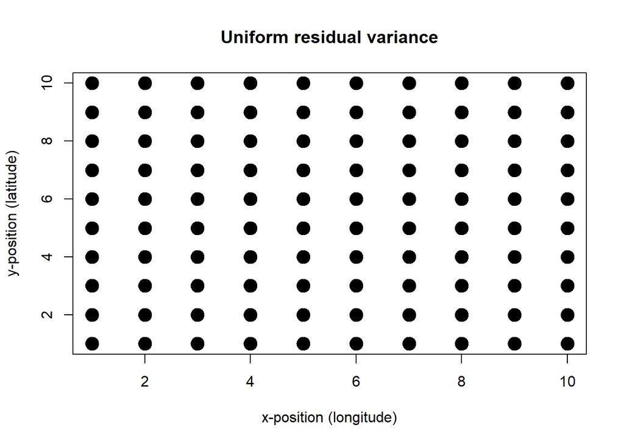

```r
x_cord <- 1:10
y_cord <- 1:10
d <- expand.grid(x_cord,y_cord)
plot(d,pch=19,col="black",cex=2,xlab="x-position (longitude)",ylab="y-position (latitude)"
     ,main="Uniform residual variance")
```

This is the plot to show the hierarchical study design

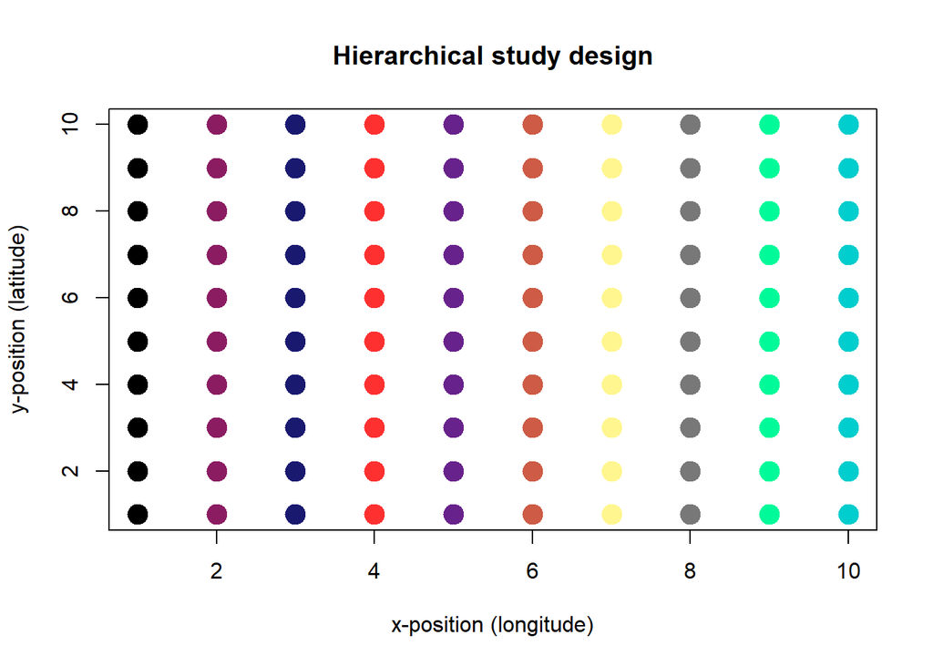

```r
patches <-c("black","maroon4","midnightblue","firebrick1","darkorchid4",
            "coral3","khaki1","gray47","mediumspringgreen","cyan3")

plot(d,pch=19,col=patches,cex=2,xlab="x-position (longitude)",ylab="y-position (latitude)"
     ,main="Hierarchical study design")
```

These are the data for the uniform data design –> epsilon is for all sample units from the same distribution $\varepsilon \sim N(0,1)$

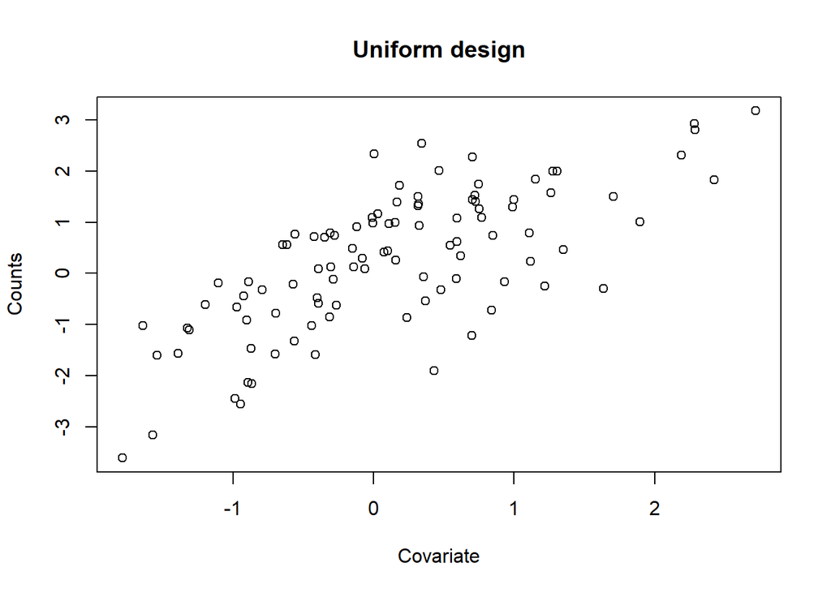

```r
n = 100 #sampling sides
set.seed(7)
x = rnorm(n)
sample.id = 1:n
beta1 = 0
beta2 = 1
sigma = 1
L = beta1 + beta2*x
y = L + rnorm(n, sd = sigma)
data <- data.frame(sampling_unit=sample.id,covariate=x,counts=y,predictor=L)
plot(x,y,xlab="Covariate",ylab="Counts"
     ,main="Uniform design")
```

These are the data for the hierarchical data design –> epsilon is part of two distributions 1. the same error distributions for all sampling units as above $\varepsilon \sim N(0,1)$ 2. the added variance of the plot-level effects $a_p \sim N(0,\sigma^2_P)$ as such we have $\epsilon_i = \varepsilon_i + a_{p(i)}$

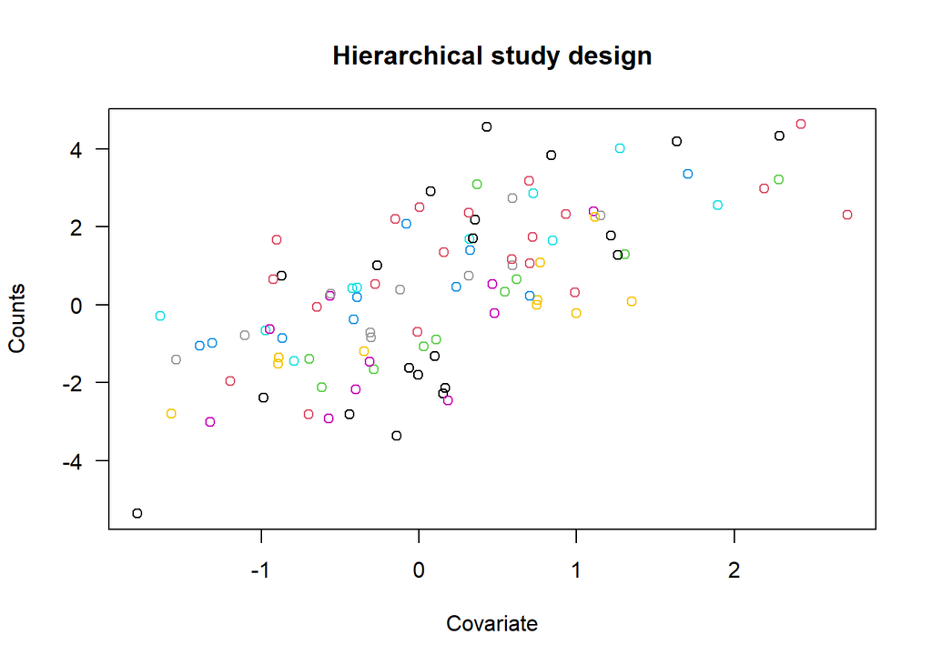

```r
n = 100
L = beta1 + beta2*x
np = 10
plot.id = c(rep(1:10,10))
sigma.plot = 1
ap = rnorm(np, sd = sigma.plot)
a = ap[plot.id]
y = L + a + rnorm(n, sd = sigma)
plot.id = as.factor(plot.id)
data2 <- data.frame(sampling_unit=sample.id,plots=plot.id,covariate=x,counts=y,predictor=L,plot_effect=a)
plot(x,y,col = plot.id, las = 1,xlab="Covariate",ylab="Counts"
     ,main="Hierarchical study design")
```

## Code to better understand non-heirarchical and heirarchical errors

I model here the abundance / population size (`y`) of a single species in the uniform landscape pictured above, at each site `i`. The average population size is $\alpha = \beta_1 = 450$, but also varies depending on the local site’s value of the environmental covariate $x_i$, as well as unstructured (non-hierarchical) error (unexplained variation in population size) $\epsilon_i$. I include an impact of $\beta = \beta_2 = 1.23$ - for each unit change in *x*, there is a corresponding increase by 1.23 of *y*.

```r
n <- 100
x1 <- rep(1,n)
x2 <- x
beta1 <- 450
beta2 <- 1.23
L <- beta1*x1 + beta2*x2
```

Currently, the population size values follow perfectly the expectation given by the impact of *x* on *y*:

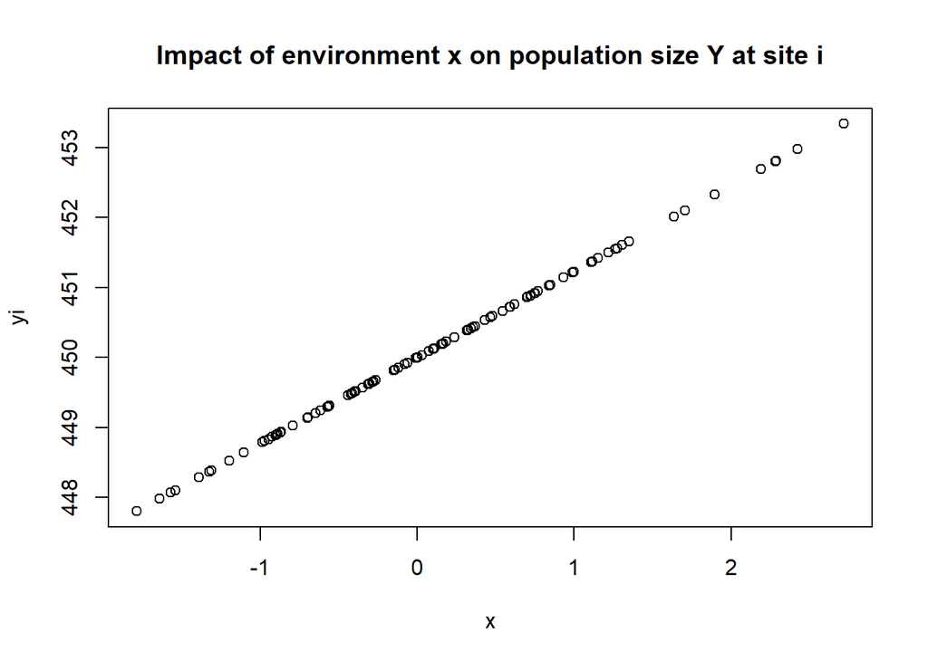

```r
plot(x,L,main="Impact of environment x on population size Y at site i",ylab="yi")
```

However, each sampling site has some unexplained error, or some unexplained deviation from the average population size after taking the environmental covariate *x* into account. We still hypothesize / state that the population size values are drawn from a single, shared distribution, with a shared center $L_i$ and a shared variance $\sigma^2$. The response variable cannot be expected be fully predicted by the explanatory variable, and there will be residuals. The residual variation is assumed to be normally distributed, as $\epsilon_i \sim N(0,\sigma^2)$, where $\sigma$ is the standard deviation.

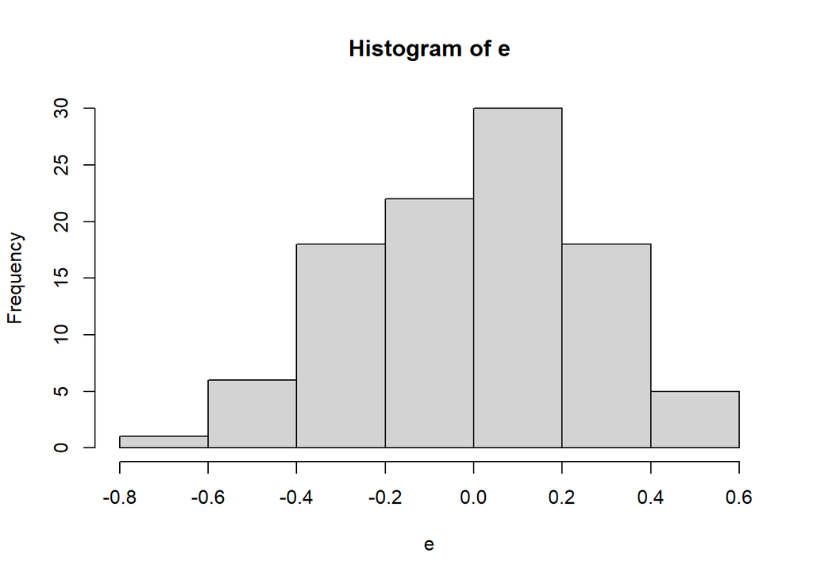

```r
sigma <- 0.25
e <- rnorm(n,0,sigma)
y <- L + e
hist(e)
```